# Reproducible research course project 1: personal movement study

Chongliang Luo

8/27/2021

## Loading and preprocessing the data

```r
require(data.table)
# read in the data from url directly
dt <- fread("curl https://d396qusza40orc.cloudfront.net/repdata%2Fdata%2Factivity.zip | funzip")
dt
```

```
##        steps       date interval
##     1:    NA 2012-10-01        0
##     2:    NA 2012-10-01        5
##     3:    NA 2012-10-01       10
##     4:    NA 2012-10-01       15
##     5:    NA 2012-10-01       20
##    ---
## 17564:    NA 2012-11-30     2335
## 17565:    NA 2012-11-30     2340
## 17566:    NA 2012-11-30     2345
## 17567:    NA 2012-11-30     2350
## 17568:    NA 2012-11-30     2355
```

## What is mean total number of steps taken per day?

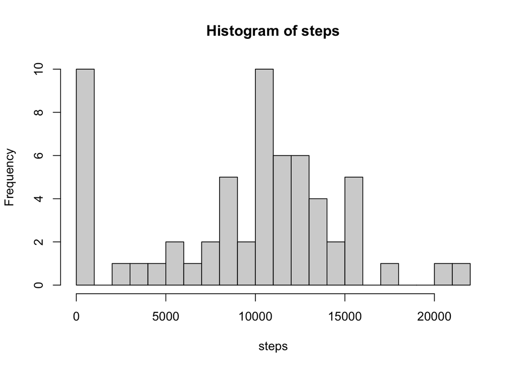

[output not shown]

```r
# Histogram of the total number of steps taken each day
dt.day <- dt[,.(steps=sum(steps, na.rm=T)), by=date]
dt.day[,hist(steps, breaks=25)]
```

```r
# Mean and median number of steps taken each day
dt.day[,mean(steps)]
```

```
## [1] 9354.23
```

```r
dt.day[,median(steps)]
```

```
## [1] 10395
```

Notice that during the 2-month period (10/01/2012 - 11/30/2012), the daily number of steps is between 10000 and 15000 for 28 days, and the mean and median number of steps taken each day are 9354.23 and 10395 respectively.

## What is the average daily activity pattern?

```r
# Time series plot of the average number of steps taken
dt.int <- dt[,.(steps.mean=mean(steps, na.rm=T),
                steps.median=median(steps, na.rm=T)), by=interval]
n.int <- 24*60/5 # number of 5-min intervals in a day
dt.int[,plot(steps.mean ~ c(1:n.int), xlab='Time',
             ylab='Average steps in each 5-min interval', xaxt='n', type='l')]
```

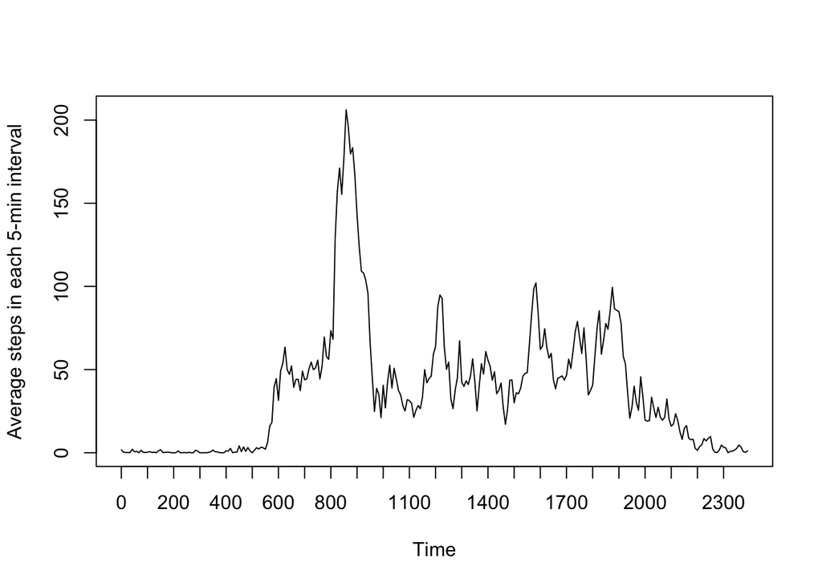

```r
axis(1,seq(0,n.int-12,by=12)+1, dt.int$interval[seq(0,n.int-12,by=12)+1])
```

```r
# The 5-minute interval that, on average, contains the maximum number of steps
dt.int[which.max(steps.mean), interval]
```

```
## [1] 835
```

We can see that the daily movement peaks at around 9am, 12pm, 4pm and 7pm. The 5-minute interval that, on average, contains the maximum number of steps is 8:35-8:40am.

## Imputing missing values

We impute the missing steps of any 5-min interval by the median steps of that interval across all days. This is reasonable as many of the intervals have sparse steps (e.g. barely no steps between 12am and 5am). We then use the imputed step counts to check the distribution of total number of steps taken each day.

```r
dt.int
```

```
##      interval steps.mean steps.median
##   1:        0  1.7169811            0
##   2:        5  0.3396226            0
##   3:       10  0.1320755            0
##   4:       15  0.1509434            0
##   5:       20  0.0754717            0
##  ---
## 284:     2335  4.6981132            0
## 285:     2340  3.3018868            0
## 286:     2345  0.6415094            0
## 287:     2350  0.2264151            0
## 288:     2355  1.0754717            0
```

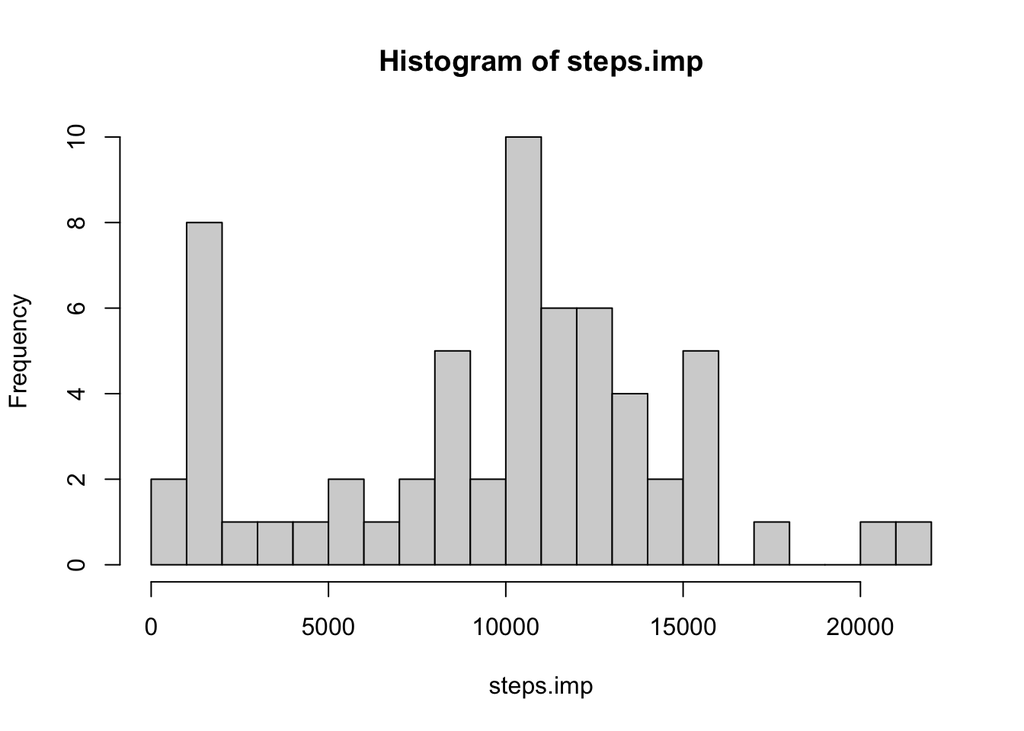

[output not shown]

```r
# impute the missing steps by the median steps of that interval across all days
dt[,steps.imp:=steps][is.na(steps), steps.imp:=dt.int$steps.median[match(interval, dt.int$interval)]]

# Histogram of the total number of steps taken each day after missing values are imputed
dt[,.(steps.imp=sum(steps.imp, na.rm=T)), by=date][,hist(steps.imp, breaks=25)]
```

Notice that the distribution of steps taken each day after imputation is close to that before imputation. By comparing the two histograms, steps of 8 days were below 1000, but are imputed as between 1000 and 2000.

## Are there differences in activity patterns between weekdays and weekends?

```r
# the average number of steps taken per 5-minute interval across weekdays and weekends
dt[,weekday:=ifelse(weekdays(date)%in%c('Saturday', 'Sunday'), 'weekend', 'weekday')]
dt.weekday <- dt[,.(steps.mean=mean(steps.imp)),by=.(interval,weekday)]
dt.weekday[,idx:=rep(1:n.int, 2)] # add index for intervals for convenience of making the plot
dt.weekday
```

```
##      interval weekday  steps.mean idx
##   1:        0 weekday  2.02222222   1
##   2:        5 weekday  0.40000000   2
##   3:       10 weekday  0.15555556   3
##   4:       15 weekday  0.17777778   4
##   5:       20 weekday  0.08888889   5
##  ---
## 572:     2335 weekend 11.00000000 284
## 573:     2340 weekend  5.87500000 285
## 574:     2345 weekend  1.62500000 286
## 575:     2350 weekend  0.00000000 287
## 576:     2355 weekend  0.00000000 288
```

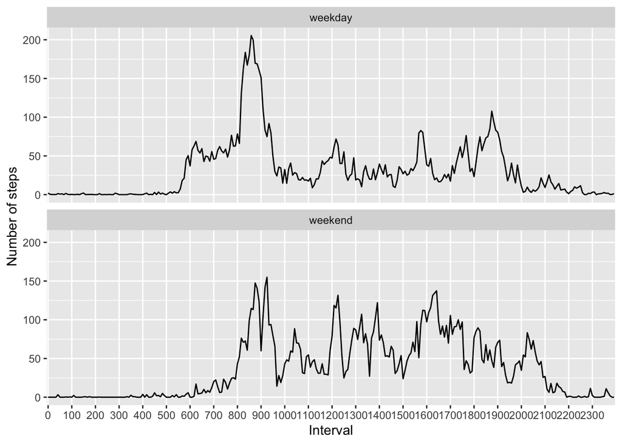

```r
require(ggplot2)
ggplot(dt.weekday, aes(x=idx, y=steps.mean))+
  facet_wrap(~weekday,nrow=2) + geom_line() +
  labs(x='Interval', y='Number of steps') +
  scale_x_discrete(breaks=seq(0,n.int-12,by=12)+1,
                   labels=dt.int$interval[seq(0,n.int-12,by=12)+1],
                   limits=seq(0,n.int-12,by=12)+1)
```

```r
dt.weekday[,.(total=sum(steps.mean)),by=weekday]
```

```
##    weekday     total
## 1: weekday  8972.489
## 2: weekend 10998.375
```

We see that compared to weekdays, there are few steps in the morning until 8am, and more steps in the evening between 8 and 9. Also, the steps during weekends are more averaged than that during weekdays, and the total steps on average is 8972.489 in a weekday, and 10998.375 in a weekend day.